# Using *rstanarm*

See [*here*](http://mc-stan.org/rstanarm/) for the official documentation.  
See [*here*](https://mc-stan.org/users/documentation/case-studies/pool-binary-trials-rstanarm.html) for a complete case study.

## Introduction

- In frequentist inference, we care more about the probability of observing some random sample, given some fixed parameters.

$$p(\mathbf y \mid \boldsymbol \theta)$$

- In Bayesian inference, we care more about the probability of parameters, given some fixed data.

  $$p(\boldsymbol \theta \mid \mathbf y)$$

  Furthermore, Bayesian inferences include prior information to get more stable estimates and predictions. And uncertainty is characterized using simulations from probability distributions (instead of relying on standard errors or bootstrap approximations).

### Hello World (Sampling)

This is how the output of normal OLS regression will look like:

```r
f_mod <- lm(inc.party.vote ~ growth, data = hibbs)
f_mod %>%
  arm::display(digits = 2)
```

```
lm(formula = inc.party.vote ~ growth, data = hibbs)
            coef.est coef.se
(Intercept) 46.25     1.62
growth       3.06     0.70
---
n = 16, k = 2
residual sd = 3.76, R-Squared = 0.58
```

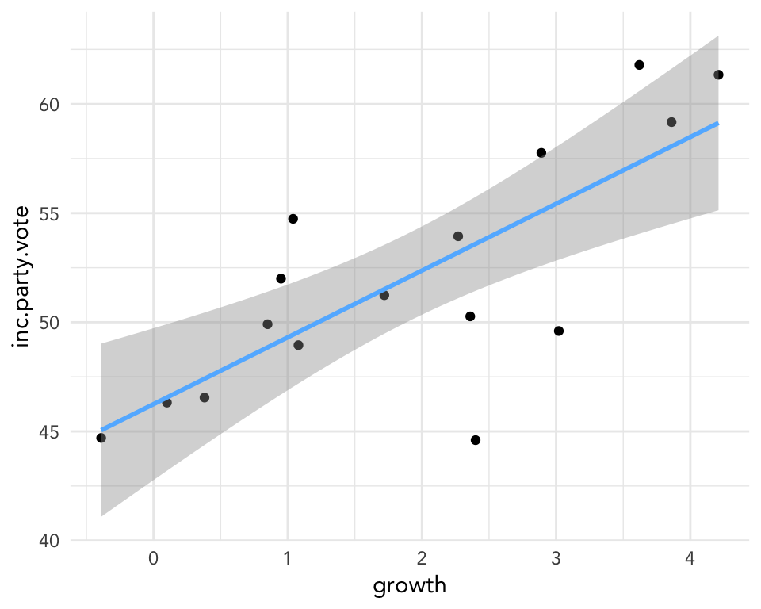

```r
hibbs %>%
  ggplot(aes(growth, inc.party.vote)) +
  geom_point() +
  geom_smooth(method = lm, color = "steelblue1")
```

And this is how the output of the same regression, fitted through `rstanarm`, looks like:

```r
b_mod <- stan_glm(inc.party.vote ~ growth, data = hibbs)
```

```r
b_mod %>%
  summary(digits = 2)
```

```
Model Info:

 function:     stan_glm
 family:       gaussian [identity]
 formula:      inc.party.vote ~ growth
 algorithm:    sampling
 priors:       see help('prior_summary')
 sample:       4000 (posterior sample size)
 observations: 16
 predictors:   2

Estimates:
                mean   sd     2.5%   25%    50%    75%    97.5%
(Intercept)    46.23   1.74  42.73  45.13  46.21  47.36  49.54
growth          3.06   0.74   1.60   2.58   3.05   3.52   4.51
sigma           3.98   0.80   2.76   3.42   3.87   4.40   5.86
mean_PPD       52.06   1.43  49.24  51.12  52.06  52.98  54.83
log-posterior -51.87   1.30 -55.23 -52.47 -51.53 -50.92 -50.39

Diagnostics:
              mcse Rhat n_eff
(Intercept)   0.03 1.00 2972
growth        0.01 1.00 2987
sigma         0.02 1.00 2501
mean_PPD      0.03 1.00 3211
log-posterior 0.03 1.00 1717

For each parameter, mcse is Monte Carlo standard error, n_eff is a crude measure of effective sample size, and Rhat is the potential scale reduction factor on split chains (at convergence Rhat=1).
```

The contents of this object include things that are usually unavailable for regular `lm()` or `glm()` objects. For example:

```r
draws <- as_tibble(b_mod)

draws %>%
  gather(key = parameters, value = draw) %>%
  group_by(parameters) %>%
  summarise(
    Median = median(draw),
    MAD_SD = mad(draw)
    )
```

```
# A tibble: 3 x 3
  parameters  Median MAD_SD
  <chr>        <dbl>  <dbl>
1 (Intercept)  46.2   1.66
2 growth        3.05  0.693
3 sigma         3.87  0.721
```

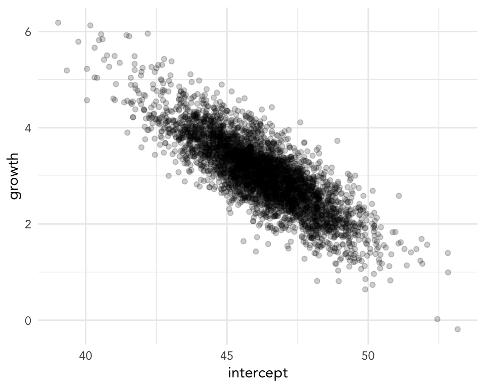

```r
g <- draws %>%
  rename(intercept = `(Intercept)`) %>%
  ggplot(aes(intercept, growth)) +
  geom_point(alpha = 0.2)

g
```

```r
b_mod$coefficients
```

```
(Intercept)      growth
  46.212251    3.046147
```

```r
b_mod$covmat
```

```
            (Intercept)     growth
(Intercept)    3.031714 -1.0541819
growth        -1.054182  0.5448431
```

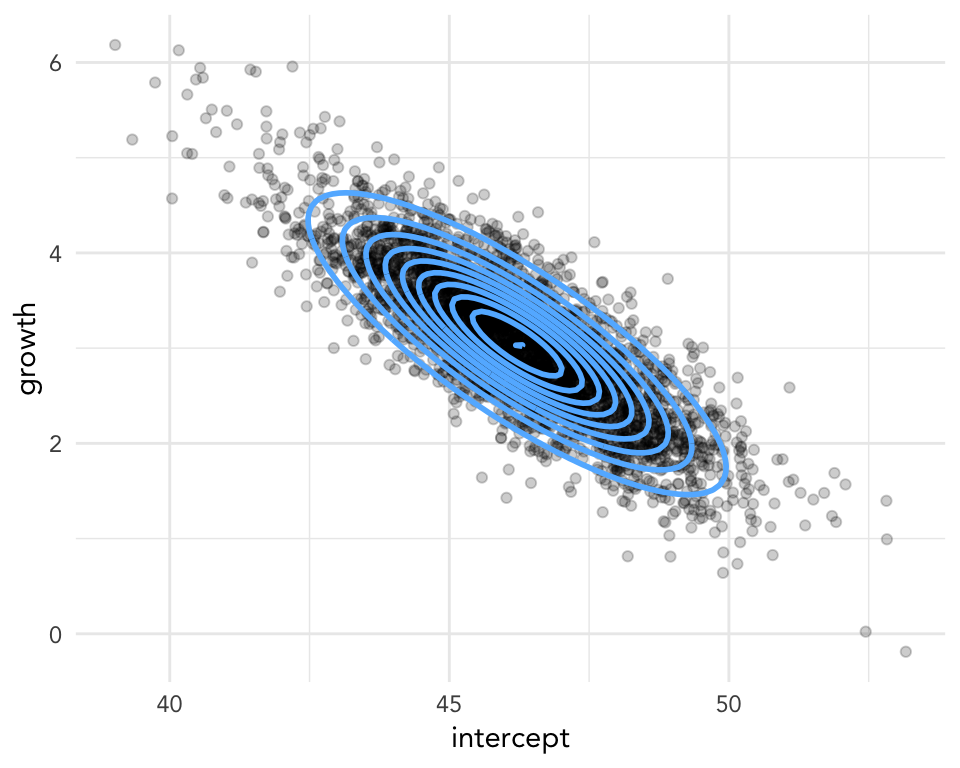

```r
df <- crossing(  ## parameter grid
  a = seq(40, 52, length.out = 100),
  b = seq(0, 6, length.out = 100)) %>%
  mutate(  ## joint density
    dens = map2(a, b, cbind) %>%
      map_dbl(mvtnorm::dmvnorm,
              mean = b_mod$coefficients,
              sigma = b_mod$covmat)
    )

g + geom_contour(data = df,
                 aes(a, b, z = dens),
                 color = "steelblue1", bins = 10, size = 1)
```

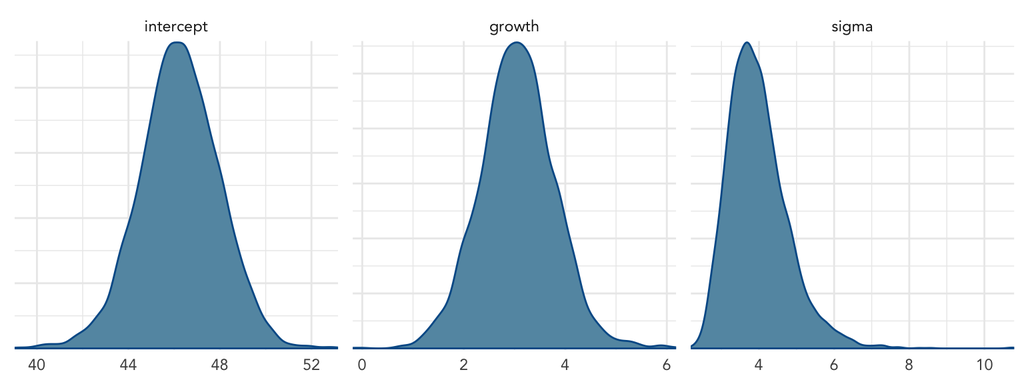

```r
draws %>%
  rename(intercept = `(Intercept)`) %>%
  bayesplot::mcmc_dens(
    pars = c("intercept", "growth", "sigma"),
    facet_args = list(nrow = 1))
```

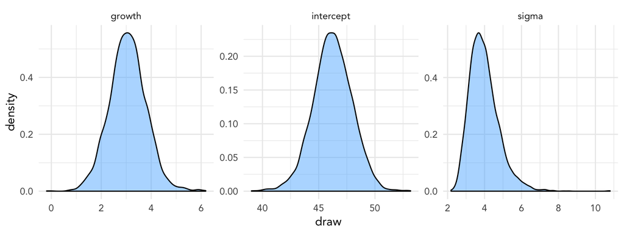

```r
draws %>%
  rename(intercept = `(Intercept)`) %>%
  gather(key = pars, value = draw) %>%
  ggplot(aes(x = draw)) +
  geom_density(fill = "steelblue1", alpha = 0.5) +
  facet_wrap(~pars, scales = "free")
```

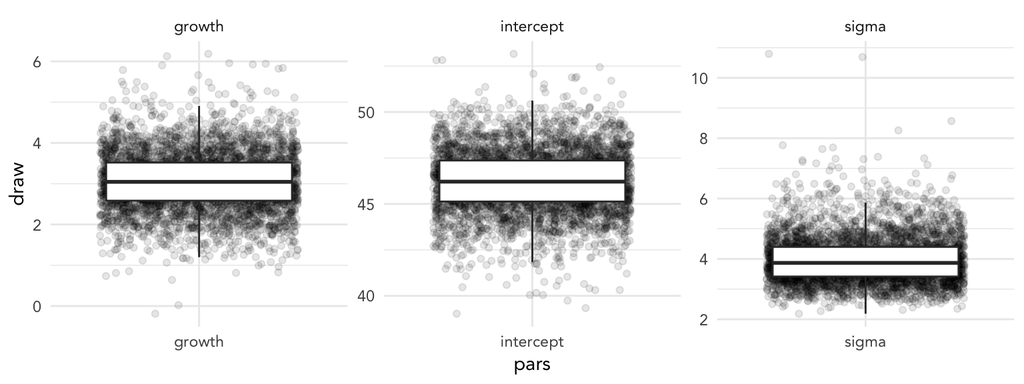

```r
draws %>%
  rename(intercept = `(Intercept)`) %>%
  gather(key = pars, value = draw) %>%
  ggplot(aes(x = pars, y = draw)) +
  geom_jitter(alpha = 0.1) +
  geom_boxplot(outlier.color = NA) +
  facet_wrap(~pars, scales = "free")
```

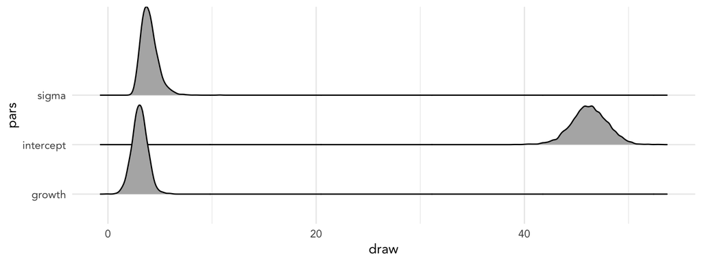

```r
draws %>%
  rename(intercept = `(Intercept)`) %>%
  gather(key = pars, value = draw) %>%
  ggplot(aes(x = draw, y = pars)) +
  ggridges::geom_density_ridges()
```

```r
b_mod$algorithm
```

```
[1] "sampling"
```

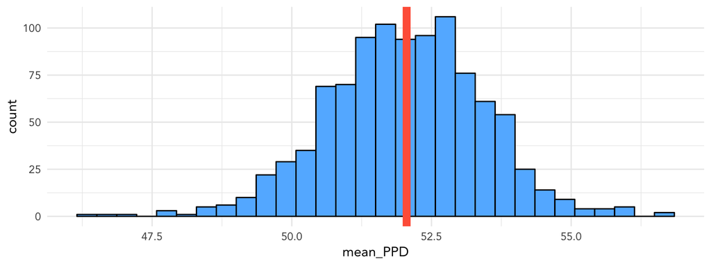

```r
ggplot(NULL, aes(x = b_mod$stanfit@sim$samples[[1]]$mean_PPD)) +
  geom_histogram(fill = "steelblue1", color = "black") +
  geom_vline(xintercept = mean(hibbs$inc.party.vote), size = 3, color = "tomato") +
  labs(x = "mean_PPD")
```

**Note**.

- `posterior_linpred()` yields simulations of the possible values of $\boldsymbol \eta = \alpha + \beta \mathbf x$, with variation coming from the posterior uncertainty of the coefficients.
- `posterior_predict()` yields simulations of the possible values of $\mathbf y^\text{rep} = \alpha + \beta \mathbf x + \epsilon$. This is also known as the *posterior predictive distribution* of the data.

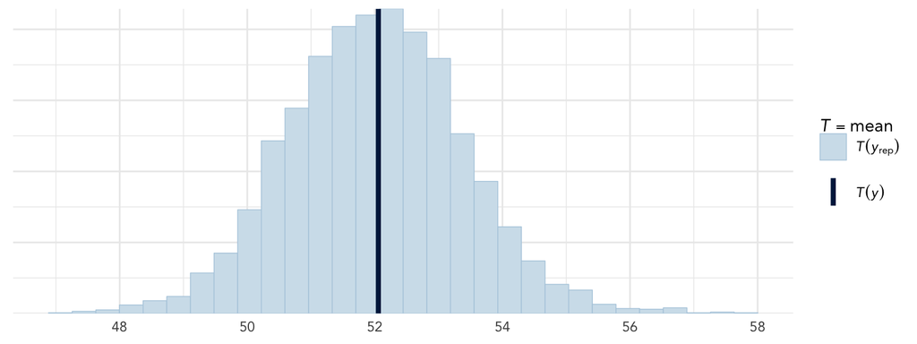

```r
bayesplot::ppc_stat(y = hibbs$inc.party.vote,
                    yrep = posterior_predict(b_mod), stat = mean)
```

The `posterior_predict()` function is simply a short hand for the following procedure:

```r
draws <- draws %>%
  rename(a = `(Intercept)`, b = growth)

n_sims <- nrow(draws)
n_obs <- nrow(hibbs)

yrep <- array(NA, dim = c(n_sims, n_obs))
for (i in 1:n_obs) {
  yrep[ , i] <- rnorm(
    n = n_sims,
    mean = draws$a + draws$b * hibbs$growth[i],
    sd = draws$sigma)
}

dim(yrep)
```

```
[1] 4000   16
```

```r
dim(posterior_predict(b_mod))
```

```
[1] 4000   16
```

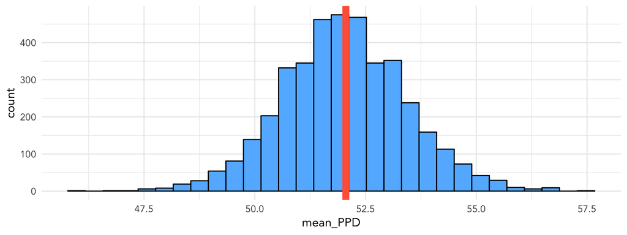

```r
ggplot(NULL, aes(x = apply(yrep, 1, mean))) +
  geom_histogram(color = "black", fill = "steelblue1") +
  geom_vline(xintercept = mean(hibbs$inc.party.vote),
             size = 3, color = "tomato") +
  labs(x = "mean_PPD")
```

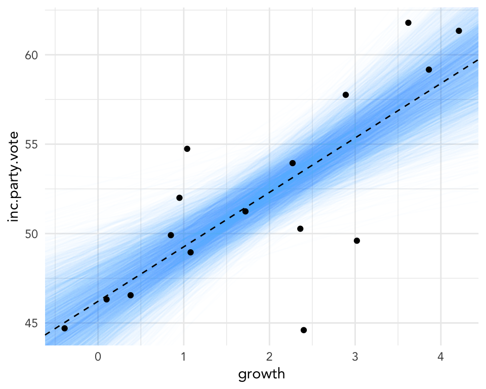

```r
hibbs %>%
  ggplot(aes(growth, inc.party.vote)) +
  geom_abline(
    data = draws,
    mapping = aes(intercept = a, slope = b),
    alpha = 0.01, color = "steelblue1") +
  geom_abline(
    intercept = b_mod$coefficients[1],
    slope = b_mod$coefficients[2],
    linetype = "dashed") +
  geom_point()
```

#### Forecasts!

Suppose we are interested in predicting the election outcomes when growth is 2%. We simply do as follows:

```r
new_df <- tibble(growth = 2)
ypred <- posterior_predict(b_mod, newdata = new_df)

cat("Predicted Clinton percentage of 2-party vote: ", median(ypred),
    ", with s.e. ", sd(ypred), "\n\nPr(Clinton Win) = ",
    mean(ypred > 50), sep = "")
```

```
Predicted Clinton percentage of 2-party vote: 52.318, with s.e. 4.155331

Pr(Clinton Win) = 0.721
```

Then again, it’s hard to believe a 2% growth estimate without any uncertainty attached.

Suppose that our best estimate of economic growth was 2%, but with some uncertainty that will be expressed as a normal distribution with standard deviation 0.3%. We can then *propagate the uncertainty* in this predictor to obtain a forecast distribution that more completely expresses our uncertainty:

```r
draws <- draws %>%
  mutate(x = rnorm(n_sims, mean = 2, sd = 0.3)) %>%
  mutate(ypred = rnorm(n_sims, a + b*x, sigma))

with(draws,
cat("Predicted Clinton percentage of 2-party vote: ", median(ypred),
    ", with s.e. ", sd(ypred), "\n\nPr(Clinton Win) = ",
    mean(ypred > 50), sep = ""))
```

```
Predicted Clinton percentage of 2-party vote: 52.36181, with s.e. 4.251544

Pr(Clinton Win) = 0.7165
```

Note that the standard error is slightly higher and thus, the probability of a win is slightly lower.

```r
prior_summary(b_mod)
```

```
Priors for model 'b_mod'
------
Intercept (after predictors centered)
 ~ normal(location = 0, scale = 10)
     **adjusted scale = 56.09

Coefficients
 ~ normal(location = 0, scale = 2.5)
     **adjusted scale = 10.05

Auxiliary (sigma)
 ~ exponential(rate = 1)
     **adjusted scale = 5.61 (adjusted rate = 1/adjusted scale)
------
See help('prior_summary.stanreg') for more details
```

### Hello World (MAP)

The following example gets rid of this quantity by setting `mean_PPD = FALSE`. It also sets uniform prior for all coefficients, and uses the “optimizing” algorithm instead of “sampling”.

The “optimizing” algorithm produces a MAP estimate or a *normal approximation centered at the posterior mode.* The idea is to take the Bayesian posterior distribution, and instead of sampling from it, which can be slow when the number of regression coefficients is large, we use an optimization algorithm to find its mode, and then use the curvature of the posterior density to construct a normal approximation.

This normal approximation is not perfect, especially for small datasets where there’s necessarily more uncertainty in the inference. But it can be used for speeding computations in “big data” applications.

```r
map_mod <- stan_glm(inc.party.vote ~ growth, data = hibbs,
                  prior = NULL,
                  prior_intercept = NULL,
                  prior_aux = NULL,
                  mean_PPD = FALSE,
                  algorithm = "optimizing")
```

```r
map_mod %>%
  print(digits = 2)
```

```
stan_glm
 family:       gaussian [identity]
 formula:      inc.party.vote ~ growth
 observations: 16
 predictors:   2
------
            Median MAD_SD
(Intercept) 46.18   1.48
growth       3.12   0.69

Auxiliary parameter(s):
      Median MAD_SD
sigma 3.52   0.61

------
* For help interpreting the printed output see ?print.stanreg
* For info on the priors used see ?prior_summary.stanreg
```

```r
prior_summary(map_mod)
```

```
Priors for model 'map_mod'
------
Intercept (after predictors centered)
 ~ flat

Coefficients
 ~ flat

Auxiliary (sigma)
 ~ flat
------
See help('prior_summary.stanreg') for more details
```

## Diagnostic plots

```r
library(bayesplot)
bayesplot_theme_set(theme_minimal(base_family = "Avenir"))
color_scheme_set("viridis")

n_pars <- nuts_params(b_mod)
```

```r
rhat(b_mod)
```

```
(Intercept)      growth       sigma
  0.9995866   0.9997194   1.0001138
```

```r
b_mod %>%
  as.array() %>%
  mcmc_trace(facet_args = list(ncol = 1),
             np = n_pars)
```

```
No divergences to plot.
```

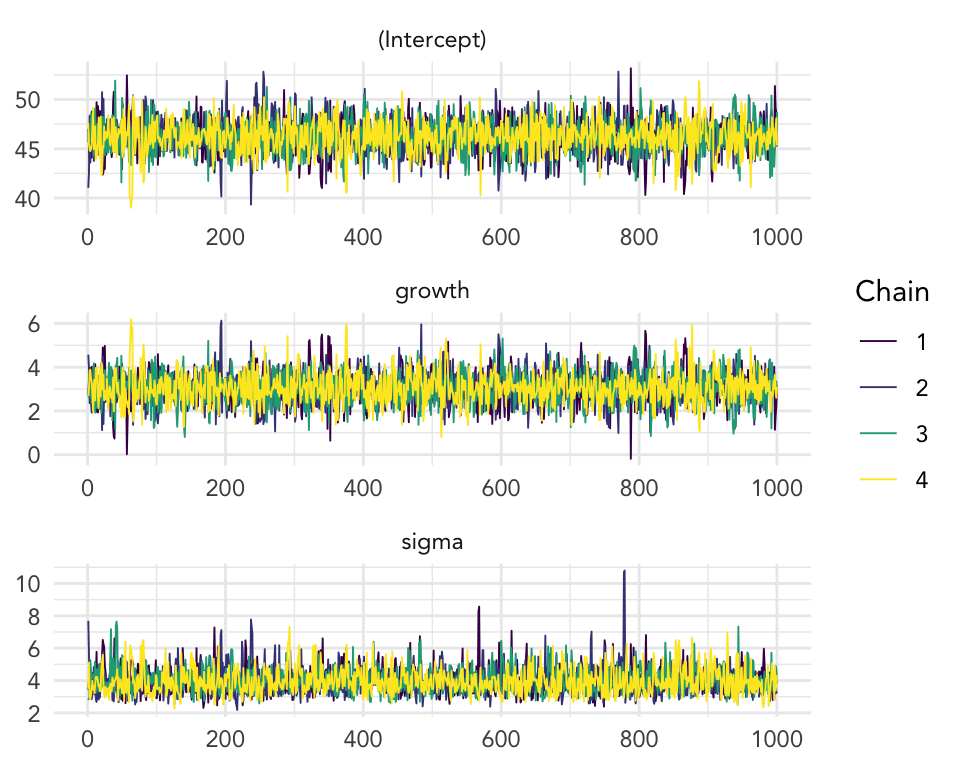

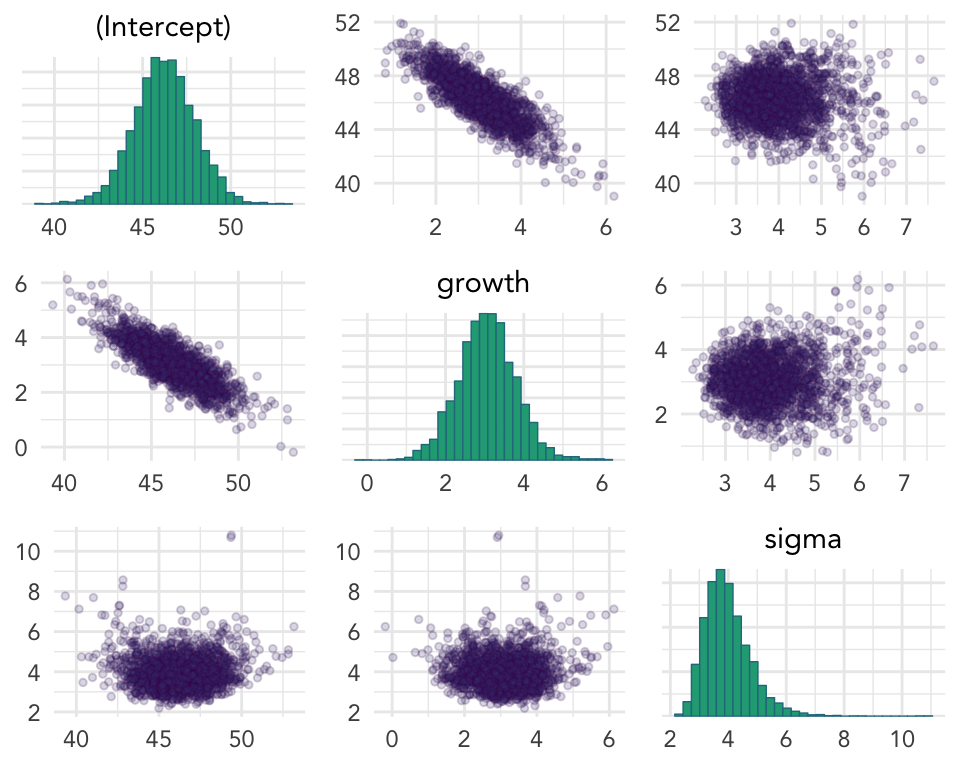

```r
b_mod %>%
  as.array() %>%
  mcmc_pairs(off_diag_args = list(size = 1, alpha = 0.2),
             np = n_pars)
```